# Coding Challenge 2 (Undergraduate version)

2024-09-22

# Instructions

This version of Coding Challenge 2 is specifically for students enrolled in the COMM section (undergraduate) of the class. If you are a DACSS graduate student, please use the DACSS version instead.

The topic for this coding challenge is *Trend Analysis*. Please review the lecture slides before proceeding to complete the coding challenge.

## What you need to do?

*Edit the Code*: You will see code presented in R code chunks. Follow the prompts to edit the code as needed. *Run the Code*: After making your edits, click *Run* to check if the code produces the correct output. *Focus on Changes*: Pay special attention to the part of the code marked as xxxx; this is where you need to make your changes.

Once you have completed all required tasks, click the **Knit** button, a HTML document will be generated that includes both content as well as the output of any embedded R code chunks within the document. The .html file is saved to your working directory by default.

We will start this activity in class. You can collaborate with your group; however, each student is expected to complete their own work. Please submit the final .html file by *11:59 PM on October 4, 2024 (Friday)*, to receive participation credit.

# Step 1: Load the data

## know which dataset you are assigned to

### Group 1: New England Patriots: https://curiositybits.cc/files/Patriots.csv

### Group 2: Philadelphia Eagles: https://curiositybits.cc/files/Eagles.csv

### Group 3: UMass football: https://curiositybits.cc/files/UMass-Football.csv

### Group 4: UMass hockey: https://curiositybits.cc/files/UMass-Hockey.csv

Revise the code below to import the CSV file nfl.csv as df1, and your group’s data as a dataframe called df2.

```r
library(readr) # load the library readr
library(ggplot2)
library(ggthemes)
library(lubridate)
library(reshape2)
library(dplyr)
library(stringr)
library(tidyr)
df1 <- read_csv("https://curiositybits.cc/files/nfl.csv")
df2 <- read_csv("https://curiositybits.cc/files/Eagles.csv")
```

# Step 2:

Run the code below. No need to change anything. The rbind() function combine df1 and df2 into a new dataframe called df. The new dataframe contains post the NFL posts and the posts from the data your group is assigned to.

```r
df <- rbind(df1, df2)
```

# Step 3

Suppose the analytical goal is to compare the daily average like counts between the NFL and the team represented in your group’s data.

Revise the code below to calculate the average daily likes.

Hint: You need to group the data by date and account name (the column named ‘Account’).

```r
df$created_date <- ymd_hms(df$`Post Created`)  #something needs to be changed here.
df$created_date <- with_tz(df$created_date,"America/New_York")
df$created_date <- as.Date(df$created_date)


df$date_label <- as.factor(df$created_date)
df$account_name <- as.factor(df$Account)

daily_count <- df %>%
  group_by(date_label, account_name) %>%
  summarise(avg_likes = mean(Likes))
daily_count <- daily_count %>% pivot_longer(cols = -c(date_label, account_name), names_to = "variable", values_to = "value")
```

# Step 4

Based on the daily_count created from the previous step, revise the code below to create a ggplot to show and compare the daily average likes of the two teams.

Change the plot title to ‘Daily Average Likes’ and change the y axis title to “average likes”

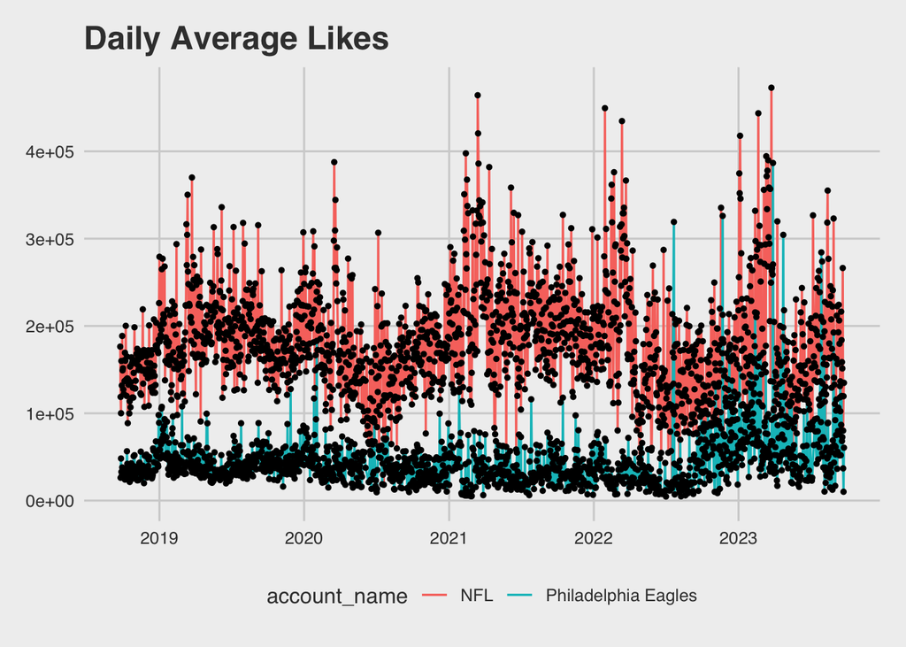

```r
library(ggplot2)
library(ggthemes)

daily_count$date_label <- as.Date(daily_count$date_label)

ggplot(data = daily_count[daily_count$variable== "avg_likes",], aes(x = date_label, y = value, group = account_name)) +   #something needs to be changed here.
  geom_line(linewidth = 0.6, alpha = 1.7, aes(color = account_name)) + #something needs to be changed here.
  geom_point(size = 1) +
  ylim(0, NA) +
  #scale_fill_manual(values=moma.colors("Smith", 3))+
  theme(legend.title=element_blank(), axis.title.x = element_blank()) +
  ylab("average likes") +
  ggtitle("Daily Average Likes") +
  theme_fivethirtyeight(base_size = 12, base_family = "sans")
```